# Домашка №1

## Задача 1 (6 баллов)

Предположим у нас есть матрица такого вида:

$$\left(\begin{array}{cc}
1 & 3 & 0 & 1\\
2 & 3 & 3 & 3\\
3 & 0 & 1 & 1\\
4 & 0 & 3 & 3\\
\end{array}\right)$$

Цифры в первом столбце означают номер футбольной команды ($1$ $-$ Bayer, $2$ $-$ Barcelona, $3$ $-$ Olympiacos, $4$ $-$ Real Madrid). Цифры во $2$, $3$ и $4$ колонках соответственно очки данной команды ($3$ $-$ команда выиграла, $0$ $-$ проиграла, $1$ $-$ команда сыграла в ничью). То есть, например, первая строка в матрице означает, что Bayer выиграл первую игру, вторую проиграл, а третью игру сыграл в ничью.

Пусть команда проходит в следующий тур, если в сумме накопила $6$ или более очков. Вывести номера команд, которые прошли в следующий тур и номера команд, которые не прошли. Вывод может выглядеть так:

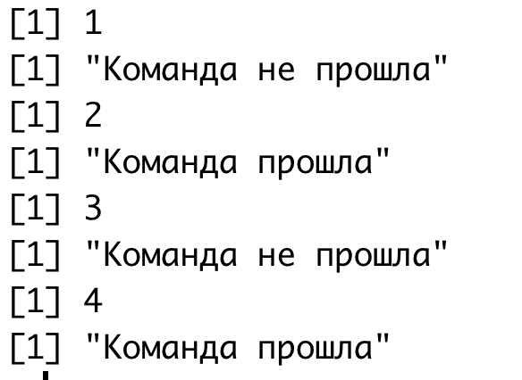

В задаче можно пользоваться встроенной в *R* функцией `sum()`. Она принимает несколько значений, и выдает их сумму. Также она может принять на вход любой массив.

Если задачу оформите в виде функции, то $+ 1$ балл. Если напишите свою функцию `my_sum()`, которая будет делать тоже самое, что и встроенная функция `sum()`, тогда можете не делать **задачу** $3$ и все равно получите $+ 3$ балла.

## Задача 2 (2 балла)

Есть $3$ числа. Нужно вывести наибольшее из них. Каждое число задается в отдельную переменную. Это задачка не на поиск максимума внутри массива, в котором лежат $3$ числа!

## Задача 3 (3 балла)

Написать функцию `my_sum()`, которая будет вычислять сумму элементов в массиве.

## Задача 4 (3 балла)

На вход подается число $n$ и $k$. Посчитать сумму чисел от $1$ до $n$, каждое из которых возводится в степень $k$.

То есть, например, для **n = 4, k = 3** нужно посчитать:
$$1^3 + 2^3 + 3^3 + 4^3$$
А вот пример для **n = 5, k = 2**:
$$1^2 + 2^2 + 3^2 + 4^2 + 5^2$$

## Задача 5 (8 баллов)

Вывести на экран таблицу умножения от $1$ до $10$. На выходе должна получиться матрица такого вида:

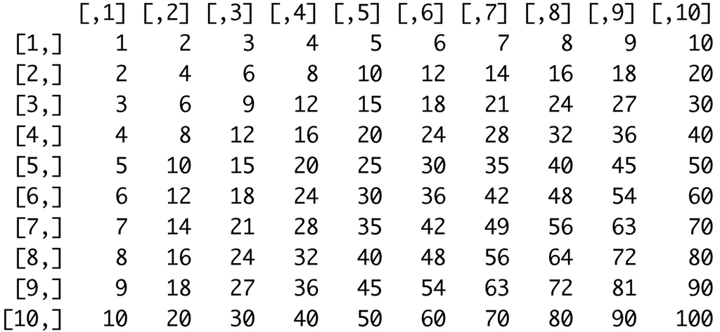

Для этой задачи вам понадобится встроенная функция `append()`. Она добавляет к массиву элемент. Рассмотрим, как она работает на примере:

```r
x <- c(1,2,3,4)
x <- append(x, 5)
print(x)
```

```
## [1] 1 2 3 4 5
```

**Подсказка 2:** Массив из чисел легко превратить в матрицу